# Survival_Analysis_GROUP 1

#### 2.2.1 Comparison of Marital Status by Residential Status

We ran a chi-square test to determine if there is a statistically significant relationship between the Marital Status and Residential status of patients. The P-value obtained of $0.4472$ is greater than the conventional significance level of $0.05$. Thus we fail to reject the null hypothesis that there is no significant association between the two variables.

```r
#smaller subset
subset_data2 <- subset_data %>%
  select(Marital, Facility_Type)

#omitt NA values
subset_data2 <- na.omit(subset_data2)

#create table
table(subset_data2$Marital, subset_data2$Facility_Type)
```

```
##
##                 Homecare In-patient
##   Not Separated       79          7
##   Separated           90         13
```

```r
#chi test
chisq.test(subset_data2$Marital, subset_data2$Facility_Type)
```

```
##
##  Pearson's Chi-squared test with Yates' continuity correction
##
## data:  subset_data2$Marital and subset_data2$Facility_Type
## X-squared = 0.57764, df = 1, p-value = 0.4472
```

We then plotted a side-by-side bar-plot of the two variables, however the relationships shown are not statistically significant.

The bar-plot shows that for both Separated and Not Separated patients, majority are Homecare patients. Furthermore, for both Homecare and In-patients majority of patients are Separated rather than Not Separated.

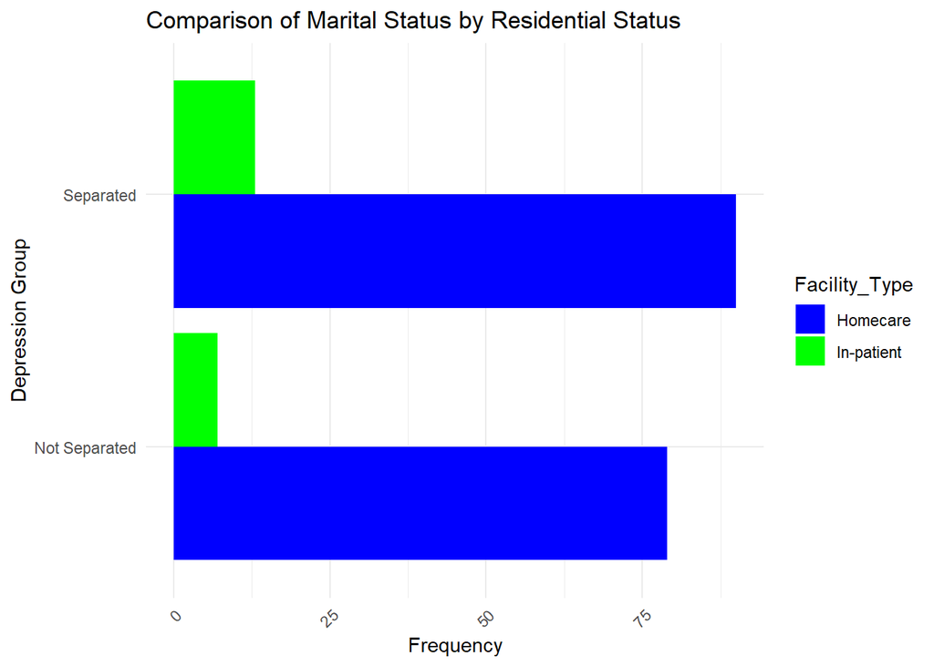

```r
#plot barplot
ggplot(subset_data2, aes(x = Marital, fill = Facility_Type)) +
  geom_bar(position = "dodge", na.rm = TRUE) +
  labs(title = "Comparison of Marital Status by Residential Status",
       x = "Depression Group",
       y = "Frequency") +
  scale_fill_manual(values = c("Homecare" = "blue", "In-patient" = "green")) +
  theme_minimal() +
  theme(axis.text.x = element_text(angle = 45, hjust = 1)) +
  coord_flip()
```

#### 2.2.2 Comparison of Depression Severity and Marital Satatus

The ordinal variable created in Q1 is `Depression_severity` . Let us compare this to the `Marital` variable using a **chi-square test**, to determine if there is an association between depression state and relationship status.

The below output of the chi-square test shows a P-Value of $0.00129$, which is less than the chosen significance level of $0.05$. Thus, there is a statistically significant association between depression severity and marital status.

```r
#add depression_severity variable to subset_data
subset_data$depression_severity <- mental_health$depression_severity

#tabulate both depression_severity and marital
table(subset_data$depression_severity)
```

```
##
##        None-Minimal     Mild depression Moderate depression   Moderately Severe
##                  42                  76                  39                  28
##   Severe depression
##                  13
```

```r
table(subset_data$Marital)
```

```
##
## Not Separated     Separated
##            95           103
```

```r
#run chi-square test
chisq.test(subset_data$depression_severity, subset_data$Marital)
```

```
##
##  Pearson's Chi-squared test
##
## data:  subset_data$depression_severity and subset_data$Marital
## X-squared = 17.901, df = 4, p-value = 0.00129
```

We will create a side-by-side bar chart to compare the depression severity levels and `separated` and `not separated` marital status groups.

The bar-plot reveals a distinct pattern where individuals classified under the lower levels of depression, (`None-Minimal` and `Mild depression`) predominantly belong to the `Not Separated` marital status group. Conversely, for those categorized under the `Severe depression`, `Moderately Severe`, and `Moderate depression` groups there is a noticeable prevalence of individuals classified as `Separated`. This trend suggests a correlation between higher levels of depression and marital separation.

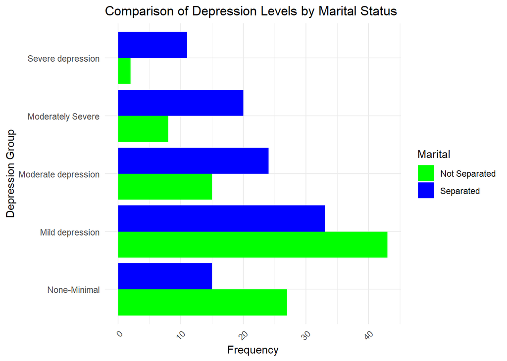

```r
# Create a bar plot
ggplot(subset_data, aes(x = depression_severity, fill = Marital)) +
  geom_bar(position = "dodge") +
  labs(title = "Comparison of Depression Levels by Marital Status",
       x = "Depression Group",
       y = "Frequency") +
  scale_fill_manual(values = c("Separated" = "blue", "Not Separated" = "green")) +
  theme_minimal() +
  theme(axis.text.x = element_text(angle = 45, hjust = 1)) + coord_flip()
```

#### 2.2.3 Survival Analysis

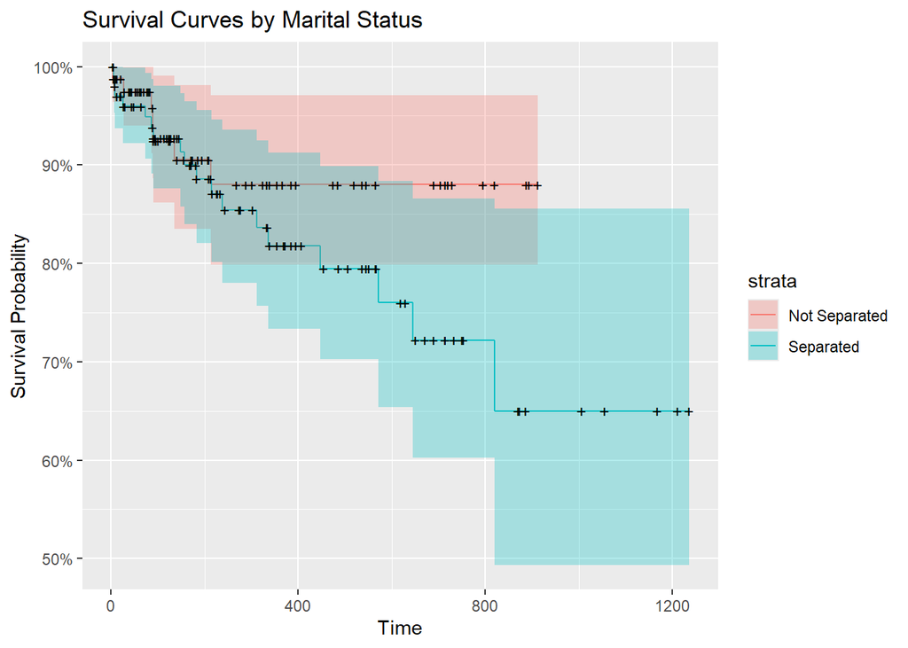

```r
#plot survival function
surv_fit3 <- survfit(Surv(survival_time, status) ~ Marital , data=subset_data)

autoplot(surv_fit3) + labs(x = "Time", y = "Survival Probability", title = "Survival Curves by Marital Status")
```

**Log-Rank Test**

The output from the log rank test indicates the results of a statistical test comparing survival distributions between two groups categorized by marital status (`Marital`). In this analysis with 185 total observations (13 excluded due to missing data), the chi-squared statistic is 1.4 with 1 degree of freedom, resulting in a p-value of $0.2$, which is greater than the conventional significance level of $0.05$. This p-value suggests that there is no statistically significant difference in survival between the groups (`Marital=Not Separated` and `Marital=Separated`), as the observed differences in survival times are not statistically significant at the conventional significance level of 0.05. *Therefore, based on these results, we do not have sufficient evidence to reject the null hypothesis that the survival distributions across different marital statuses are similar.*

```r
surv_diff <- survdiff(Surv(survival_time, status) ~ Marital , data=subset_data); surv_diff
```

```
## Call:
## survdiff(formula = Surv(survival_time, status) ~ Marital, data = subset_data)
##
## n=185, 13 observations deleted due to missingness.
##
##                         N Observed Expected (O-E)^2/E (O-E)^2/V
## Marital=Not Separated  82        7     9.89     0.846      1.41
## Marital=Separated     103       18    15.11     0.554      1.41
##
##  Chisq= 1.4  on 1 degrees of freedom, p= 0.2
```

**Log-Rank Test on Kaplan Meier Curve**

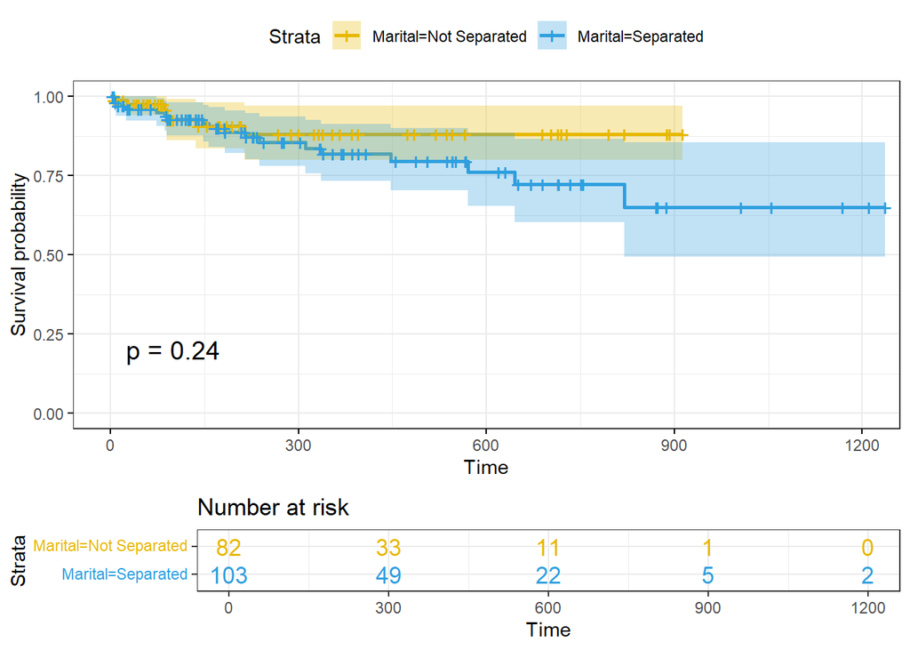

```r
ggsurvplot(surv_fit3,
pval = TRUE, conf.int = TRUE,
risk.table = TRUE,
risk.table.col = "strata",
ggtheme = theme_bw(),
palette = c("#E7B800", "#2E9FDF"))
```

### **2.3 Distribution of Length Separated Variable**

We will create a bar chart for the `Length_Separated` variable in column L, which answers the question: “If widowed/divorced/separated, for how long have you been widowed/divorced/separated?” The response categories are:

- Last six months – `<6m`
- More than six months but less than one year – `6m < 1`
- One year to below three years – `1<3`
- Three years to below five years – `3<5`
- More than five years – `>5`

Let us examine the `Length-Separated` variable for any discrepancies in categorization.

```r
#examine variable
unique(subset_data$Length_Separated)
```

```
## [1] "More than 5 years" "NA"                NA
## [4] "3<5"               ">5"                "1<3"
## [7] ">50,000"           "<6m"
```

The “More than 5 years” and “>50,000” categories need to be re-coded to a standardized “>5”. This ensures consistency in our data analysis. Furthermore, we filter the data-set to include only those who are separated, as they are the only individuals we want to consider for the `Length_Separated` variable.

This prepares the data for creating a bar chart to visualize the distribution of separation durations.

```r
#filter for only separated individuals
filtered_data <- subset_data %>%
  filter(Marital == "Separated")

#standaardise the >5 category
filtered_data <- filtered_data %>%
  mutate(Length_Separated = ifelse(Length_Separated %in% c("More than 5 years", ">50,000"), ">5", Length_Separated))
#view results
filtered_data
```

```
## # A tibble: 103 × 10
##    Date_Started        Date_Ended          Event Marital   Length_Separated
##    <dttm>              <dttm>              <chr> <chr>     <chr>
##  1 2024-04-16 00:00:00 2024-06-04 00:00:00 <NA>  Separated >5
##  2 2022-12-06 00:00:00 2024-06-04 00:00:00 <NA>  Separated >5
##  3 2024-01-29 00:00:00 2024-06-04 00:00:00 <NA>  Separated >5
##  4 2024-03-01 00:00:00 2024-06-04 00:00:00 <NA>  Separated >5
##  5 2024-04-01 00:00:00 2024-06-04 00:00:00 <NA>  Separated 3<5
##  6 2024-01-01 00:00:00 2024-04-01 00:00:00 <NA>  Separated >5
##  7 2024-02-01 00:00:00 2024-06-04 00:00:00 <NA>  Separated 1<3
##  8 2023-11-01 00:00:00 2024-01-26 00:00:00 Died  Separated 3<5
##  9 2022-12-01 00:00:00 2024-06-04 00:00:00 <NA>  Separated >5
## 10 2024-05-01 00:00:00 2024-05-31 00:00:00 <NA>  Separated 1<3
## # ℹ 93 more rows
## # ℹ 5 more variables: Reason_Caregiver <chr>, Facility_Type <chr>,
## #   status <dbl>, survival_time <dbl>, depression_severity <fct>
```

The bar chart illustrates the distribution of the length of time individuals have been separated. The highest count is in the “>5” category, indicating that the majority of individuals have been separated for more than five years. The “3<5” category follows, showing a significant number of individuals separated for three to five years. The “1<3” category has fewer individuals, and the “<6m” category has the least. This distribution suggests that longer separations are more common among the respondents in the data, with a substantial portion having been separated for extended periods.

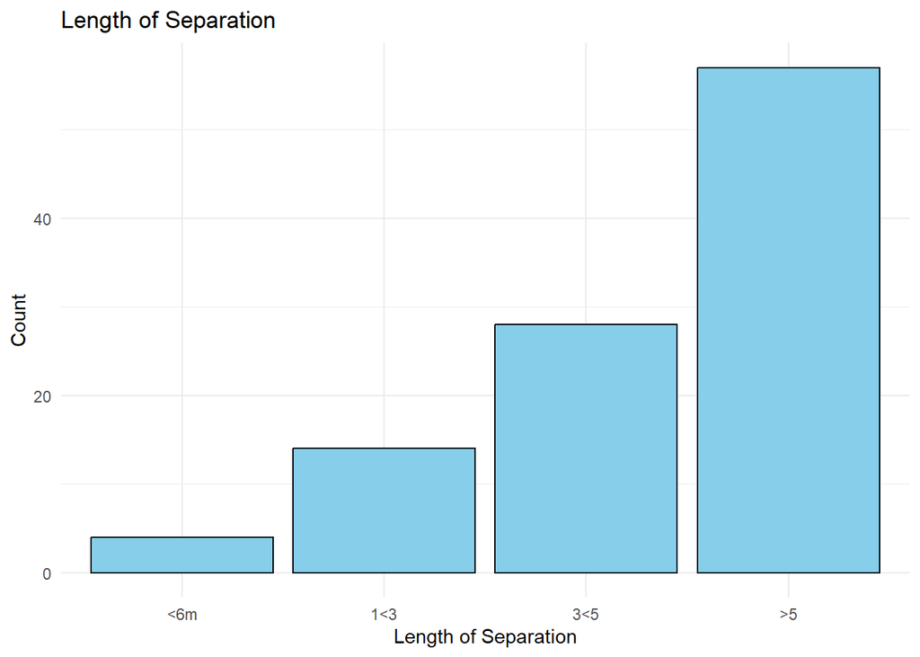

```r
# Convert Length_Separated to an ordered factor
filtered_data$Length_Separated <- factor(filtered_data$Length_Separated,
                                         levels = c("<6m", "1<3","3<5", ">5"), # Replace with actual levels in desired order
                                         ordered = TRUE)

# Create the bar plot
ggplot(filtered_data, aes(x = Length_Separated)) +
  geom_bar(fill = "skyblue", color = "black") +
  labs(title = "Length of Separation",
       x = "Length of Separation",
       y = "Count") +
  theme_minimal()
```

#### 2.3.1 Comparison of Length Separated and Residential Status

We ran a chi-square test to determine if there is a significant association between the a patients length of separation and their residential status. We used a simulated p-value due to low value counts for the chi-square test. The P-value obtained of $0.9325$ is greater than the conventional significance level of $0.05$. Thus we fail to reject the null hypothesis that there is no significant association between the two variables.

```r
#create table
table(filtered_data$Length_Separated, filtered_data$Facility_Type)
```

```
##
##       Homecare In-patient
##   <6m        4          0
##   1<3       12          2
##   3<5       25          3
##   >5        49          8
```

```r
#chi test
chisq.test(filtered_data$Length_Separated, filtered_data$Facility_Type, simulate.p.value = TRUE, B = 2000)
```

```
##
##  Pearson's Chi-squared test with simulated p-value (based on 2000
##  replicates)
##
## data:  filtered_data$Length_Separated and filtered_data$Facility_Type
## X-squared = 0.80858, df = NA, p-value = 0.933
```

We then plotted a side-by-side bar-plot visualising the distribution of patient’s length of separation, categorised by their residential status; however, any relationships observed are not significant. The bar-plot shows that only homecare patients have been separated for less than 6 months. Following the distribution of the length separation variable, majority of patients have been separated for more than 5 years, with the count of patients increasing with every longer-duration category. This is true for both in-patients and homecare patients.

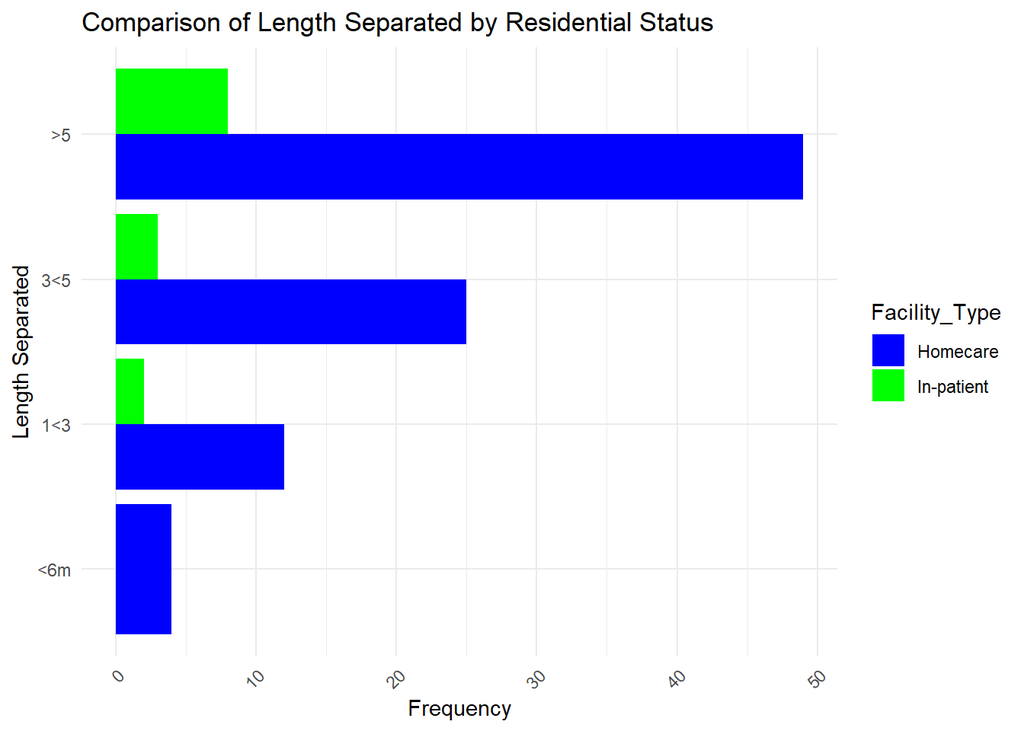

```r
#plot barplot
ggplot(filtered_data, aes(x = Length_Separated, fill = Facility_Type)) +
  geom_bar(position = "dodge", na.rm = TRUE) +
  labs(title = "Comparison of Length Separated by Residential Status",
       x = "Length Separated",
       y = "Frequency") +
  scale_fill_manual(values = c("Homecare" = "blue", "In-patient" = "green")) +
  theme_minimal() +
  theme(axis.text.x = element_text(angle = 45, hjust = 1)) +
  coord_flip()
```

### **2.4 Summary for `Reason_Caregiver`** Variable

We summarised the variable `Reason_Caregiver` in column BH, that is question 35, “What is the main reason that made you bring your patient to Care 360?”. The variable has 36 unique responses, and thus can be summarised into larger categories for similar responses.

First we examined the unique values of the variable:

```r
as.matrix(unique(patient_data$Reason_Caregiver))
```

```
##       [,1]
##  [1,] "Patient Condition"
##  [2,] "Chronic Condition"
##  [3,] "Assist"
##  [4,] "Recommended by a doctor"
##  [5,] "ompanionship and post care"
##  [6,] "Companionship"
##  [7,] "Preference"
##  [8,] "Close monitoring epilepsy"
##  [9,] "Adequate care"
## [10,] "Family engagement"
## [11,] NA
## [12,] "Patient discharged"
## [13,] "Recovery"
## [14,] "Patient lives alone"
```

[output cut: 23 more lines]

We then computed the counts and percentage of responses per category, for better understanding of the distribution of responses. This computation shows that the categories with the highest percentage responses are ‘Patient Condition’ ( $18.69\%$ ), ‘Care and support’ ( $12.63\%$ ), ‘Companionship’ ( $11.11\%$ ), ‘Convenience’ ( $7.58\%$ ) and ‘Family engagement’ ( $7.07%$ ).

```r
# Summarize the Reason_Caregiver variable
reason_summary <- patient_data %>%
  group_by(Reason_Caregiver) %>%
  summarise(Count = n()) %>%
  arrange(desc(Count)) %>%
  mutate(Percentage = (Count / sum(Count)) * 100)

#omit NA values
reason_summary <- reason_summary[-6,]

# Display the summary
print(reason_summary)
```

```
## # A tibble: 36 × 3
##    Reason_Caregiver  Count Percentage
##    <chr>             <int>      <dbl>
##  1 Patient Condition    37      18.7
##  2 Care and support     25      12.6
##  3 Companionship        22      11.1
##  4 Convinience          15       7.58
##  5 Family engagement    14       7.07
##  6 Recovery              8       4.04
##  7 Total Care            8       4.04
##  8 Monitoring            6       3.03
##  9 Support               6       3.03
## 10 Assist                5       2.53
## # ℹ 26 more rows
```

As the variable has 36 unique responses, we can further summarise the categories into 7 main reasons, by merging the categories as follows:

**Category**

Values

**Patient Condition**

- Patient Care
- Specialized Care
- Condition
- Recommended by a doctor
- Chronic Condition

**Care & Support**

- Support
- Assist
- Provide Care
- Extra help
- Better Care
- Personalised Care
- Care and support
- Specialised care

**Companionship**

- Loneliness
- Companionship
- Companionship and Care
- Companionship and Support
- Compassion
- Companionship and support
- Companionship and care
- Compassionate

**Convenience**

- Family Engagement
- Patient lives alone
- Accessibility
- Peace of Mind
- Preference
- Convinience
- Peace of Mind
- Family engagement

**Recovery**

- Post surgery management
- Patient discharged
- post care
- post hospital care
- Management
- Post surgery
- Post care
- ompanionship and post care
- Recovery
- Post Hospital Care

**Total Care**

- Adequate care
- Personalized care
- Total Care
- Better care

**Monitoring**

- Close monitoring
- Epilepsy
- Supervision
- Close monitoring epilepsy
- Monitoring
- Supervission

Let us summarize the variables as follows in a data-frame, getting the Total Count and Total Percentage distribution per category.

```r
# Define the groups
Patient_Condition <- c("Patient Condition","Specialized Care", "Condition", "Recommended by a doctor", "Chronic Condition")

Care_and_Support <- c("Support", "Assist", "Provide Care", "Extra help", "Better Care", "Personalised Care", "Care and support", "Specialised care")

Companionship <- c("Loneliness", "Companionship", "Companionship and Care", "Companionship and Support", "Compassion", "Companionship and support", "Companionship and care", "Compassionate")

Convenience <- c("Family Engagement", "Patient lives alone", "Accessibility", "Peace of Mind", "Preference", "Convinience", "Peace of Mind", "Family engagement")

Recovery <- c("Post surgery management", "Patient discharged", "post care", "post hospital care", "Management", "Post surgery", "Post care", "ompanionship and post care", "Recovery", "Post Hospital Care")

Total_Care <- c("Adequate care", "Personalized care", "Total Care", "Better care")

Monitoring <- c("Close monitoring", "Epilepsy", "Supervision", "Close monitoring epilepsy", "Monitoring", "Supervission")

# Summarize by groups
group_summary <- reason_summary %>%
  mutate(Group = case_when(
    Reason_Caregiver %in% Patient_Condition ~ "Patient Condition",
    Reason_Caregiver %in% Care_and_Support ~ "Care and Support",
    Reason_Caregiver %in% Companionship ~ "Companionship",
    Reason_Caregiver %in% Convenience ~ "Convenience",
    Reason_Caregiver %in% Recovery ~ "Recovery",
    Reason_Caregiver %in% Total_Care ~ "Total Care",
    Reason_Caregiver %in% Monitoring ~ "Monitoring",
    TRUE ~ "Other"
  )) %>%
  group_by(Group) %>%
  summarise(
    Total_Count = sum(Count),
    Total_Percentage = sum(Percentage)
  ) %>%
  arrange(desc(Total_Count))

# Display the summary
group_summary
```

```
## # A tibble: 7 × 3
##   Group             Total_Count Total_Percentage
##   <chr>                   <int>            <dbl>
## 1 Care and Support           46            23.2
## 2 Patient Condition          42            21.2
## 3 Convenience                35            17.7
## 4 Companionship              27            13.6
## 5 Recovery                   15             7.58
## 6 Monitoring                 10             5.05
## 7 Total Care                 10             5.05
```

We then create a bar-plot to visualize the percentage distribution per category.

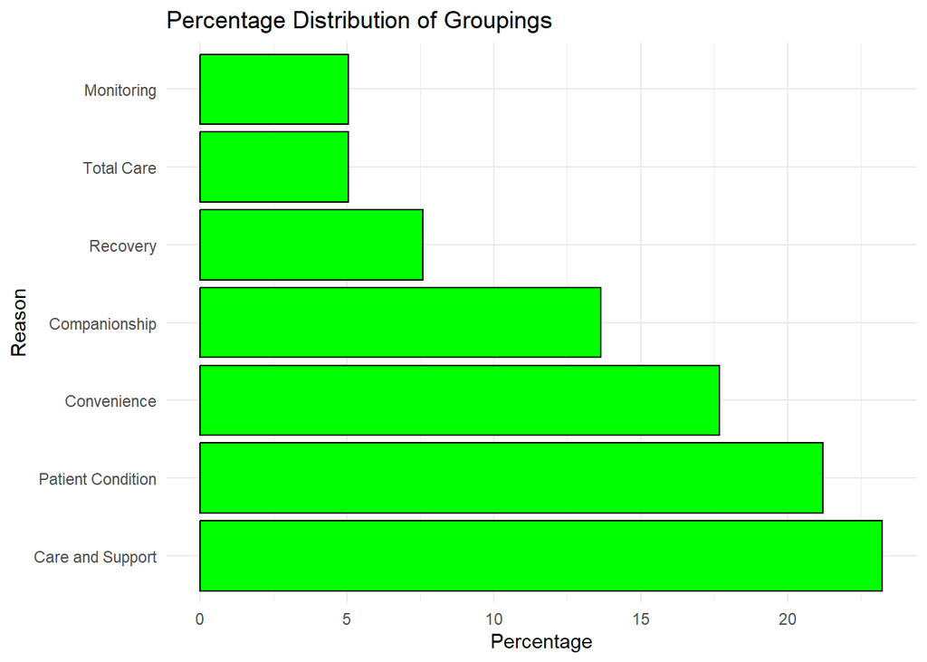

```r
# Create a bar plot for the distribution
ggplot(group_summary, aes(x = reorder(Group, -Total_Percentage), y = Total_Percentage)) +
  geom_bar(stat = "identity", fill = "green", color = "black") +
  coord_flip() + # Flip coordinates for better readability
  labs(title = "Percentage Distribution of Groupings",
       x = "Reason",
       y = "Percentage") +
  theme_minimal()
```

We then re-coded the `Reason_Caregiver` column appropriately, as follows:

```r
# Combine all groups into a named vector
group_map <- c(
  setNames(rep("Patient_Condition", length(Patient_Condition)), Patient_Condition),
  setNames(rep("Care_and_Support", length(Care_and_Support)), Care_and_Support),
  setNames(rep("Companionship", length(Companionship)), Companionship),
  setNames(rep("Convenience", length(Convenience)), Convenience),
  setNames(rep("Recovery", length(Recovery)), Recovery),
  setNames(rep("Total_Care", length(Total_Care)), Total_Care),
  setNames(rep("Monitoring", length(Monitoring)), Monitoring)
)

# Replace responses with group names
subset_data <- subset_data %>%
  mutate(Reason_Caregiver = recode(Reason_Caregiver, !!!group_map))

#view results
unique(subset_data$Reason_Caregiver)
```

```
## [1] "Patient_Condition" "Care_and_Support"  "Recovery"
## [4] "Companionship"     "Convenience"       "Monitoring"
## [7] "Total_Care"        NA
```

#### 2.4.1 Comparison of Reason_Caregiver and Residential Status

```r
#subset data
subset_data3 <- subset_data %>%
  select(Reason_Caregiver, Facility_Type)

#create table
table(subset_data3$Reason_Caregiver, subset_data3$Facility_Type)
```

```
##
##                     Homecare In-patient
##   Care_and_Support        46          0
##   Companionship           27          0
##   Convenience             28          7
##   Monitoring              10          0
##   Patient_Condition       34          8
##   Recovery                10          5
##   Total_Care              10          0
```

```r
#chi test
chisq.test(subset_data3$Reason_Caregiver, subset_data3$Facility_Type, simulate.p.value = TRUE, B = 2000)
```

```
##
##  Pearson's Chi-squared test with simulated p-value (based on 2000
##  replicates)
##
## data:  subset_data3$Reason_Caregiver and subset_data3$Facility_Type
## X-squared = 25.185, df = NA, p-value = 0.001499
```

We then created a side-by-side bar-plot of patients reasons for coming to care360 and their residential status. The bar-plot shows that inpatients are mainly brought to care360 due to patient condition, followed by convenience then recovery. *These reasons– especially patient condition and recovery– tend to suggest a higher level of care required for these patients, which aligns with why they are admitted as inpatients*.

For homecare patients, their to reason for being brought to care360 is care and support, followed by patient condition, convenience, companionship, monitoring, recovery and total care, in that order. *The top four categories–especially care and support and companionship – suggest a need for extra care and attention, but not as high as inpatients.*

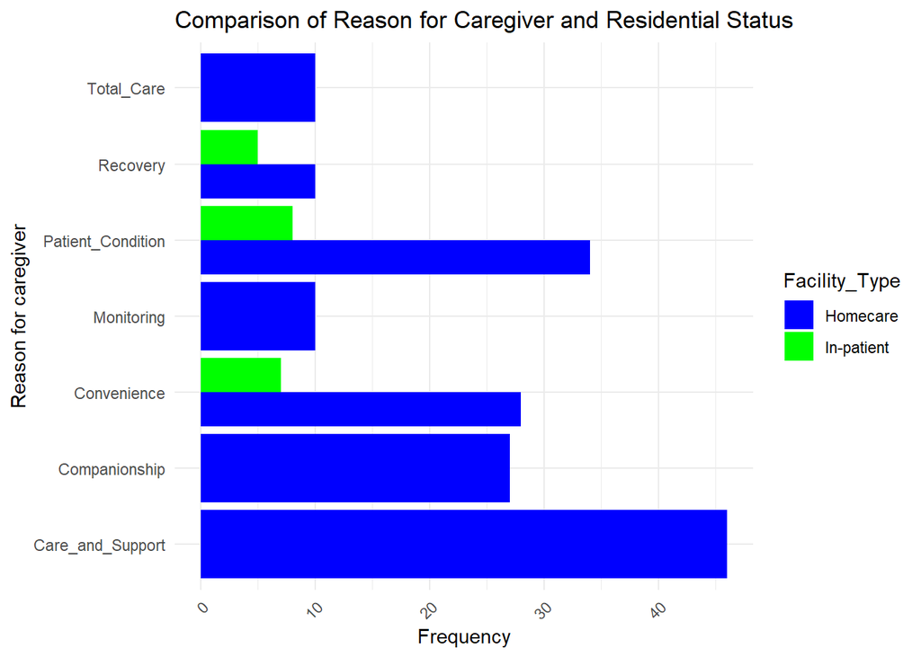

```r
#remove NA values
subset_data3 <- na.omit(subset_data3)

# Create a bar plot
ggplot(subset_data3, aes(x = Reason_Caregiver, fill = Facility_Type)) +
  geom_bar(position = "dodge") +
  labs(title = "Comparison of Reason for Caregiver and Residential Status",
       x = "Reason for caregiver",
       y = "Frequency") +
  scale_fill_manual(values = c("Homecare" = "blue", "In-patient" = "green")) +
  theme_minimal() +
  theme(axis.text.x = element_text(angle = 45, hjust = 1)) + coord_flip()
```

### 2.5 Comparison of Sex and the `Facilty_Type` Variable

**Preprocessing**

The `Sex_Patient` variable indicates the sex assigned to the patient at birth, and has four possible responses:

- Female
- Male
- Other
- Prefer not to say

First, we created a subset with the two variables of interest then examined the unique variables of the sex patient variable, to check for errors.

```r
#add desired column to the data
filtered_data2 <- data.frame(Facility_Type = subset_data$Facility_Type, Sex_Patient = patient_data$Sex_Patient)

#examine unique values for both
unique(filtered_data2$Facility_Type)
```

```
## [1] "Homecare"   "In-patient" NA
```

```r
unique(filtered_data2$Sex_Patient)
```

```
## [1] "Female" "Male"   NA
```

There are no errors, thus we then ran a chi-square test to determine whether there is a statistically significant relationship between the sex of the patient and their residential status. The P-value obtained of $0.8973$ is greater than the conventional significance level of $0.05$. Thus, we fail to reject the null hypothesis that there is no significant association between the two variables.

```r
#create table
table(filtered_data2$Facility_Type, filtered_data2$Sex_Patient)
```

```
##
##              Female Male
##   Homecare      102   66
##   In-patient     13    7
```

```r
#run chi test
chisq.test(filtered_data2$Facility_Type,filtered_data2$Sex_Patient)
```

```
##
##  Pearson's Chi-squared test with Yates' continuity correction
##
## data:  filtered_data2$Facility_Type and filtered_data2$Sex_Patient
## X-squared = 0.016662, df = 1, p-value = 0.8973
```

We then created a side-by-side bar plot to compare the relationship between the residential status of a patient and their sex. The relationships portrayed are not statistically significant.

The Bar-plot shows that overall, there are more female patients of Care360 than male patients. Both in residents and non-residents category, female patients are the majority. Furthermore, there are more Non-resident patients of care360 than resident patients.

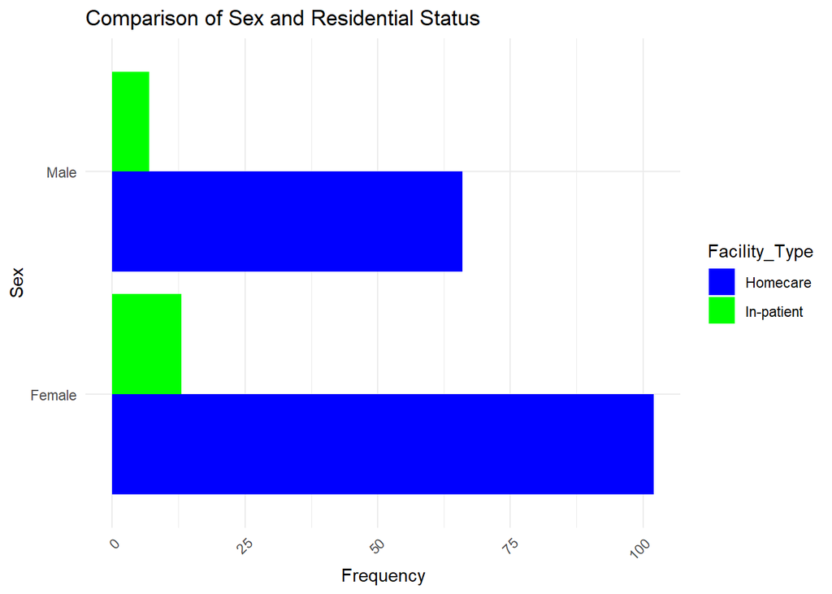

```r
#omit NA values
filtered_data2 <- na.omit(filtered_data2)

# Create a bar plot
ggplot(filtered_data2, aes(x = Sex_Patient, fill = Facility_Type)) +
  geom_bar(position = "dodge") +
  labs(title = "Comparison of Sex and Residential Status",
       x = "Sex",
       y = "Frequency") +
  scale_fill_manual(values = c("Homecare" = "blue", "In-patient" = "green")) +
  theme_minimal() +
  theme(axis.text.x = element_text(angle = 45, hjust = 1)) + coord_flip()
```